# Web Scraping with R & rvest

Dr. Matthew Hendrickson

July 9, 2020

# Topics

1. About Me
2. A Little About Web Scraping
3. Robots.txt
4. HTML & CSS
5. Web Scraping
6. The Setup
7. Scraping the Data
8. Assembling the Data
9. References & Resources

# About Me

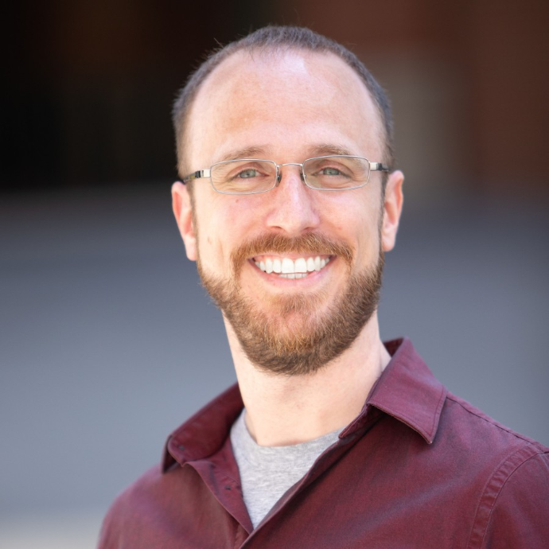

- Social Scientist by Training
  - Psychology & Music `%>%`
  - More Psychology `%>%`
  - Law & Policy
- Professional Experience (13+ years)
  - Higher Education Analyst
  - Independent Consultant
  - Research projects, data analysis, policy development, strategy, analytics pipeline solutions

# A Little About Web Scraping

“Web scraping is the process of automatically mining data or collecting information from the World Wide Web.” – Wikipedia

Web scraping is a flexible method to extract data from the internet. It can involve extracting numerical or text data.

## Use Cases

There are many uses for web scraping, including but not limited to:

1. Price monitoring
2. Sentiment analysis
3. Time series tracking and analysis
4. Brand monitoring
5. Market analysis
6. Lead generation

# Robots.txt

Always ensure - **PRIOR to scraping** - that you have rights to scrape the website.

This is critical as you can be blocked from sites or even face legal action.

## Robots.txt

Good news! You can easily check with the `robotstxt` package.

```r
paths_allowed(paths = c("https://netflix.com/"))
```

```
#> [1] FALSE
```

This example shows that Netflix does not allow you to scrape their site.

# HTML & CSS

“HTML is the standard markup language for creating Web pages.” – W3Schools

“CSS describes how HTML elements are to be displayed on screen, paper, or in other media.” – W3Schools

## HTML Structure

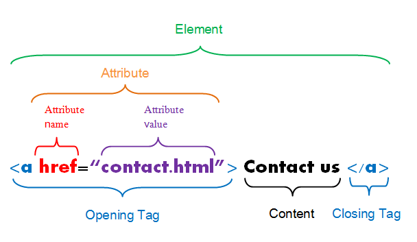

Image credit: [Professor Shawn Santo](http://www2.stat.duke.edu/~fl35/teaching/440-19F/decks/webscraping2.html#3)

## HTML Tags

HTML is strucutred with “tags.” These tags indicate portions of the page and can be called by their structure.

There are many types of tags - here are some important ones for scraping:

- `<h1>` - header tags
- `<p>` - paragraph elements
- `<ul>` - unordered bulleted list
- `<ol>` - ordered list
- `<li>` - individual list item
- `<div>` - division
- `<table>` - table

## A Little Help with CSS

If you aren’t familiar with CSS, extracting parts of a website can be daunting.

[SelectorGadget](https://selectorgadget.com/) is incredibly helpful for this purpose. However, it is only available for Chrome.

[figure not shown]

Another option is to inspect the page elements, which is available for most major browsers, including Chrome, Firefox, as developer tools.

# Web Scraping

## Scraping Methods

XPATH - useful when the node isn’t uniquely identified with CSS

# The Setup

Set up the environment to scrape the site.

```r
library(tidyverse)
library(robotstxt)
library(rvest)
```

That’s it! These are all the tools you’ll need.

### Determine a website to scrape

It only seems appropriate to pull data from Amazon regarding R books

Ensure we can scrape the site

```r
paths_allowed(paths = c("https://amazon.com/"))
```

```
#> [1] TRUE
```

We are good to scrape!

# Setting the URL

Before you can get started, you must specific the URLs to pass to the function.

```r
amazon <- read_html("https://www.amazon.com/s?k=R&i=stripbooks&rh=n%3A283155%2Cn%3A75%2Cn%3A13983&dc&qid=1592086532&rnid=1000&ref=sr_nr_n_1")
```

# Scraping Book Titles

```r
amazon %>%
  html_nodes(".s-line-clamp-2") %>%
  html_text() -> amazon_titles
head(amazon_titles)
```

```
#> [1] "\n    \n    \n        \n\n\n\n\n\n    \n        \n            \n                R for Data Science: Import, Tidy, Transform, Visualize, and Model Data\n            \n        \n        \n    \n\n\n    \n"
#> [2] "\n    \n    \n        \n\n\n\n\n\n    \n        \n            \n                The Book of R: A First Course in Programming and Statistics\n            \n        \n        \n    \n\n\n    \n"
#> [3] "\n    \n    \n        \n\n\n\n\n\n    \n        \n            \n                Advanced R, Second Edition (Chapman & Hall/CRC The R Series)\n            \n        \n        \n    \n\n\n    \n"
#> [4] "\n    \n    \n        \n\n\n\n\n\n    \n        \n            \n                R Graphics Cookbook: Practical Recipes for Visualizing Data\n            \n        \n        \n    \n\n\n    \n"
#> [5] "\n    \n    \n        \n\n\n\n\n\n    \n        \n            \n                Hands-On Programming with R: Write Your Own Functions And Simulations\n            \n        \n        \n    \n\n\n    \n"
#> [6] "\n    \n    \n        \n\n\n\n\n\n    \n        \n            \n                Discovering Statistics Using R\n            \n        \n        \n    \n\n\n    \n"
```

The element pulls a number of breaks and blank spaces.

Let’s clean this up with `str_trim`.

## The titles have a great deal of white space and breaks (`\n`), these need to be removed

```r
amazon_titles <- str_trim(amazon_titles) # Removes leading & training space
head(amazon_titles)
```

```
#> [1] "R for Data Science: Import, Tidy, Transform, Visualize, and Model Data"
#> [2] "The Book of R: A First Course in Programming and Statistics"
#> [3] "Advanced R, Second Edition (Chapman & Hall/CRC The R Series)"
#> [4] "R Graphics Cookbook: Practical Recipes for Visualizing Data"
#> [5] "Hands-On Programming with R: Write Your Own Functions And Simulations"
#> [6] "Discovering Statistics Using R"
```

This simple function returns cleaned text.

# Scraping the Book Format

```r
amazon %>%
  html_nodes("a.a-size-base.a-link-normal.a-text-bold") %>%
  html_text() %>%
  str_trim() -> amazon_format
head(amazon_format)
```

```
#> [1] "Paperback" "Kindle"    "Paperback" "eTextbook" "Paperback" "Kindle"
```

## Clean up book format values

```r
amazon_format <- str_trim(amazon_format)
head(amazon_format)
```

```
#> [1] "Paperback" "Kindle"    "Paperback" "eTextbook" "Paperback" "Kindle"
```

# Scraping the Book Price

The price structure splits price into two elements. We must pull each and combine them into a single price.

```r
amazon %>%
  html_nodes(".a-price-whole") %>%
  html_text() -> amazon_price_whole
head(amazon_price_whole)
```

```
#> [1] "39." "24." "33." "29." "42." "15."
```

## Scraping (the rest of) the Book Price

```r
amazon %>%
  html_nodes(".a-price-fraction") %>%
  html_text() -> amazon_price_fraction
head(amazon_price_fraction)
```

```
#> [1] "49" "99" "04" "99" "26" "92"
```

## Combine Price Portions

```r
amazon_price <- as.numeric(paste(amazon_price_whole, amazon_price_fraction, sep = ""))
head(amazon_price)
```

```
#> [1] 39.49 24.99 33.04 29.99 42.26 15.92
```

# Scraping the Book Rating

```r
amazon %>%
  html_nodes("i.a-icon.a-icon-star-small.a-star-small-4-5.aok-align-bottom") %>%
  html_text() -> amazon_rating
head(amazon_rating)
```

```
#> [1] "4.7 out of 5 stars" "4.3 out of 5 stars" "4.7 out of 5 stars"
#> [4] "4.3 out of 5 stars" "4.5 out of 5 stars" "4.5 out of 5 stars"
```

## Let’s trim this into a usable metric

```r
amazon_rating <- as.numeric(substr(amazon_rating, 1, 3)) # Takes 3 characters starting at 1
head(amazon_rating)
```

```
#> [1] 4.7 4.3 4.7 4.3 4.5 4.5
```

# Scraping the Book Rating Count

This element is messier and we’ll need a number of cleaning steps.

```r
amazon %>%
  html_nodes("div.a-row.a-size-small") %>%
  html_text() -> amazon_rate_n
head(amazon_rate_n)
```

```
#> [1] "\n\n\n\n    \n\n\n\n\n\n\n    \n        \n            \n            4.7 out of 5 stars\n        \n    \n    \n\n\n\n\n\n\n\n    \n\n\n\n\n\n    \n        \n            \n                426\n            \n        \n        \n    \n\n\n\n"
#> [2] "\n\n\n\n    \n\n\n\n\n\n\n    \n        \n            \n            4.3 out of 5 stars\n        \n    \n    \n\n\n\n\n\n\n\n    \n\n\n\n\n\n    \n        \n            \n                75\n            \n        \n        \n    \n\n\n\n"
#> [3] "\n\n\n\n    \n\n\n\n\n\n\n    \n        \n            \n            4.8 out of 5 stars\n        \n    \n    \n\n\n\n\n\n\n\n    \n\n\n\n\n\n    \n        \n            \n                31\n            \n        \n        \n    \n\n\n\n"
#> [4] "\n\n\n\n    \n\n\n\n\n\n\n    \n        \n            \n            4.7 out of 5 stars\n        \n    \n    \n\n\n\n\n\n\n\n    \n\n\n\n\n\n    \n        \n            \n                14\n            \n        \n        \n    \n\n\n\n"
#> [5] "\n\n\n\n    \n\n\n\n\n\n\n    \n        \n            \n            4.3 out of 5 stars\n        \n    \n    \n\n\n\n\n\n\n\n    \n\n\n\n\n\n    \n        \n            \n                49\n            \n        \n        \n    \n\n\n\n"
#> [6] "\n\n\n\n    \n\n\n\n\n\n\n    \n        \n            \n            4.5 out of 5 stars\n        \n    \n    \n\n\n\n\n\n\n\n    \n\n\n\n\n\n    \n        \n            \n                255\n            \n        \n        \n    \n\n\n\n"
```

## Clean up Rating Count

```r
amazon_rate_n <- str_trim(amazon_rate_n)    # trim \n & ' '
amazon_rate_n <- str_sub(amazon_rate_n, -5) # keep last 5 characters
amazon_rate_n <- str_trim(amazon_rate_n)    # trim leading spaces
amazon_rate_n <- as.numeric(amazon_rate_n)
head(amazon_rate_n)
```

```
#> [1] 426  75  31  14  49 255
```

# Scraping the Book Publication Date

```r
amazon %>%
  html_nodes("span.a-size-base.a-color-secondary.a-text-normal") %>%
  html_text() -> amazon_pub_dt
head(amazon_pub_dt)
```

```
#> [1] "Jan 10, 2017" "Jul 16, 2016" "May 30, 2019" "Nov 30, 2018" "Aug 2, 2014"
#> [6] "Apr 5, 2012"
```

## We need to convert this to a date to allow easier analysis

```r
amazon_pub_dt <- as.Date(amazon_pub_dt, "%b %d, %Y")
head(amazon_pub_dt)
```

```
#> [1] "2017-01-10" "2016-07-16" "2019-05-30" "2018-11-30" "2014-08-02"
#> [6] "2012-04-05"
```

# We Have the Pieces

Let’s assemble the file!

1. Titles
2. Formats
3. Prices
4. Ratings
5. Rating Counts
6. Publication Date

## Let’s Check the Scrapes

```r
length(amazon_titles)
```

```
#> [1] 18
```

```r
length(amazon_format)
```

```
#> [1] 37
```

```r
length(amazon_price)
```

```
#> [1] 37
```

```r
length(amazon_rating)
```

```
#> [1] 11
```

```r
length(amazon_rate_n)
```

```
#> [1] 16
```

```r
length(amazon_pub_dt)
```

```
#> [1] 18
```

## Wait! What?!?

An issue with scraping is sometimes you get an uneven number of records due to missing data elements.

We can fix this!

- …manually…

# Fixing the Scrapes

## Titles

All titles were populated and scraped accurately. However, due to multiple formats, these records must be repeated to fill the dataframe.

```r
amazon_titles %>%
  append(values = amazon_titles[16], after = 16) %>%
  append(values = amazon_titles[15], after = 15) %>%
  append(values = amazon_titles[14], after = 14) %>%
  append(values = amazon_titles[13], after = 13) %>%
  append(values = amazon_titles[12], after = 12) %>%
  append(values = amazon_titles[11], after = 11) %>%
  append(values = amazon_titles[11], after = 11) %>%
  append(values = amazon_titles[10], after = 10) %>%
  append(values = amazon_titles[9], after = 9) %>%
  append(values = amazon_titles[8], after = 8) %>%
  append(values = amazon_titles[7], after = 7) %>%
  append(values = amazon_titles[6], after = 6) %>%
  append(values = amazon_titles[6], after = 6) %>%
  append(values = amazon_titles[5], after = 5) %>%
  append(values = amazon_titles[5], after = 5) %>%
  append(values = amazon_titles[4], after = 4) %>%
  append(values = amazon_titles[4], after = 4) %>%
  append(values = amazon_titles[3], after = 3) %>%
  append(values = amazon_titles[2], after = 2) %>%
  append(values = amazon_titles[1], after = 1) -> amazon_titles
length(amazon_titles)
```

```
#> [1] 38
```

## Formats

Nothing needed here!

```r
length(amazon_format)
```

```
#> [1] 37
```

## Prices

Nothing needed here!

```r
length(amazon_price)
```

```
#> [1] 37
```

## Ratings

Some books do not have ratings. A book only has one rating even if it has multiple formats.

We must also account for multiple formats.

```r
amazon_rating %>%
  append(values = NA, after = 4) %>%   #  4th - no rating
  append(values = 4.8, after = 5) %>%  #  6th - missing rating
  append(values = NA, after = 6) %>%   #  7th - no rating
  append(values = 4.2, after = 12) %>% # 13th - missing rating
  append(values = 3.9, after = 13) %>% # 14th - missing rating
  append(values = 3.8, after = 14) -> amazon_rating
length(amazon_rating)
```

```
#> [1] 17
```

## Ratings

Like titles, the ratings need to be repeated to show on the correct row.

The same corrections are done here.

```r
amazon_rating %>%
  append(values = amazon_rating[16], after = 16) %>%
  append(values = amazon_rating[15], after = 15) %>%
  append(values = amazon_rating[14], after = 14) %>%
  append(values = amazon_rating[13], after = 13) %>%
  append(values = amazon_rating[12], after = 12) %>%
  append(values = amazon_rating[11], after = 11) %>%
  append(values = amazon_rating[11], after = 11) %>%
  append(values = amazon_rating[10], after = 10) %>%
  append(values = amazon_rating[9], after = 9) %>%
  append(values = amazon_rating[8], after = 8) %>%
  append(values = amazon_rating[7], after = 7) %>%
  append(values = amazon_rating[6], after = 6) %>%
  append(values = amazon_rating[6], after = 6) %>%
  append(values = amazon_rating[5], after = 5) %>%
  append(values = amazon_rating[5], after = 5) %>%
  append(values = amazon_rating[4], after = 4) %>%
  append(values = amazon_rating[4], after = 4) %>%
  append(values = amazon_rating[3], after = 3) %>%
  append(values = amazon_rating[2], after = 2) %>%
  append(values = amazon_rating[1], after = 1) -> amazon_rating
length(amazon_rating)
```

```
#> [1] 37
```

## Rating Counts

Not all titles have a rating, specifically 5 and 7

```r
amazon_rate_n %>%
  append(values = NA, after = 4) %>%
  append(values = NA, after = 6) -> amazon_rate_n
length(amazon_rate_n)
```

```
#> [1] 18
```